# UConn Football Prospect Analysis

Author

Alex Pugh

# Introduction

This data analysis focuses on the combine test scores of high school football athletes. Using data from the National Combine, this paper will try to unveal which combine tests have the best predictive power for forecasting player performance at the next level. Given that 600 athletes attend this combine annually, scouts and general managers at the collegiate level require an efficient process to evaluate each player. Discovering which metrics translate most effectively to the college game will greatly aid talent recruiters with the team building process. For the purpose of this analysis, physical measurements will not be utilized. Instead, speed, agility, and explosion metrics will be utilized.

# Specific Aims

My main goals in exploring this data set are to answer the following research questions:

- Is it possible to predict the success of a college player based on the combine scores in high school?
- Which combine testing metrics should talent evaluators focus on during the recruitment process?
- Are there any positions whose test scores matter more than others?

Answering these inqueries will reveal pertinent information about evaluating high school athletes. These findings may aid coaches, general managers, and scouts in their college recruitment process.

# Data Description

The National Combine testing data was collected from Zybeck Sports. This dataset contains nine years of test scores ranging from 2016-2024. The variables of significant interest are as follows: `Position`, `10`, `20`, `40`, `5_10_5_10`, `5_10_5_20`, `3_Cone`, `VJ_Max`, `VJ_VJ`, and `Broad Jump`. There were three seperate columns for player position in the original dataset, often containing conflicting positions for the same players. Best judgement was used in these cases, inspecting both height and weight as the best indicators.

The meanings behind the other variables of significant interest are as follows:

- `10`: Time required for a player to run the first 10 yards of a 40-yard dash (in seconds)
- `20`: Time required for a player to run the first 20 yards of a 40-yard dash (in seconds)
- `40`: Time required for a player to run a 40-yard dash (in seconds)
- `5_10_5_10`: Time required for a player to complete half of the 20-yard shuttle (in seconds)
- `5_10_5_20`: Time required for a player to complete the 20-yard shuttle (in seconds)
- `3_Cone`: Time required for a player to complete the 3-cone drill (in seconds)
- `VJ_Max`: Total distance jumped for three attempts at the vertical jump (in inches)
- `VJ_VJ`: Average vertical jump distance from three attempts (in inches)
- `Broad Jump`: Distance jumped during broad jump (in inches)

In attempt to define a successful player (this will be disucced in the following section in detail), data from Division I football conferences are incorporated into the dataset. This included data solely contains player names and positions.

```python
import pandas as pd
import numpy as np

combine = pd.read_csv("data/ZBK Data - National Combine.csv")
NFL = pd.read_csv("/Users/alexpugh/UConn 2024 Spring/Football/data/NationalAndNFLCombinePlayers.csv")
All_Conference = pd.read_csv("data/Combine_All_Conference.csv")

All_Conference.rename(columns={'Name': 'Full Name'}, inplace=True)

combine.drop(columns=['Unnamed: 25', 'Unnamed: 26', 'Unnamed: 27', 'Unnamed: 28', 'Unnamed: 29'], inplace=True)

merged_df = pd.concat([All_Conference, NFL], ignore_index=True)
merged_df['Success'] = True
merged_df

# Identify rows where "Name" is NaN and "Full Name" is not NaN
mask_name_nan = merged_df["Name"].isna() & ~merged_df["Full Name"].isna()

# Swap values between "Name" and "Full Name" columns
merged_df.loc[mask_name_nan, "Name"] = merged_df.loc[mask_name_nan, "Full Name"]

# Identify rows where "Full Name" is NaN and "Name" is not NaN
mask_full_name_nan = merged_df["Full Name"].isna() & ~merged_df["Name"].isna()

# Swap values between "Name" and "Full Name" columns
merged_df.loc[mask_full_name_nan, "Full Name"] = merged_df.loc[mask_full_name_nan, "Name"]

merged_df.drop("Full Name", axis=1, inplace=True)
```

In order to determine whether a player’s career was successful post high school, two different criteria were used. A player either had to of been invited to the NFL combine between 1987 and 2023 or have been selected to an All-Conference team between 2019 and 2023. In order to keep consistent with Division I teams with comparable success as UConn, only the following conferences’ postseason awards were considered:

- Metro-Atlantic Conference
- Sun Belt Conference
- Conference USA
- Mountain West Conference

If a player appeared in either of these four conferences’ awards within this five year window or was invited to the combine, then they were deemed to have been successful. All other players were considered to not have been successful.

```python
combine['Success'] = False
columns_to_keep = combine.columns
merged_df = merged_df[columns_to_keep]
merged_df = merged_df[[col for col in merged_df.columns if col != 'Success'] + ['Success']]

# Define a function to check if two rows are similar based on a threshold
def are_rows_similar(row1, row2, threshold=0.5):
    num_columns = len(row1)
    num_matching_columns = np.sum(row1 == row2)
    similarity_ratio = num_matching_columns / num_columns
    return similarity_ratio >= threshold

# Drop the 'Success' column for comparison
merged_df_no_success = merged_df.drop(columns=['Success'])
combine_no_success = combine.drop(columns=['Success'])

# Create a list to store indices of duplicate rows
duplicate_indices = []

# Iterate through rows in combine DataFrame
for idx_combine, row_combine in combine_no_success.iterrows():
    # Iterate through rows in merged_df DataFrame
    for idx_merged, row_merged in merged_df_no_success.iterrows():
        # Check if the rows are similar based on the threshold
        if are_rows_similar(row_combine.values, row_merged.values):
            # If similar, add the index to the list of duplicate indices
            duplicate_indices.append(idx_combine)
            break  # Break out of the inner loop to avoid duplicates

# Update the 'Success' column in combine DataFrame where duplicates are found
combine['Success'] = combine.index.isin(duplicate_indices)

# Reorder the columns with 'Success' as the last column
combine = combine[[col for col in combine.columns if col != 'Success'] + ['Success']]
```

In order to have a sufficient sample size within each position of successful and unsuccessful players, positions had to be consolidated. All linebackers, defensive backs, offensive linemen, and defensive linemen were mapped to these generalized positions, regardless of their assignments within these groups. The counts of players within each position groupping is as follows:

```python
# Define the mapping dictionary
position_mapping = {
    'ILB': 'LB',
    'Lb': 'LB',
    'RB/WR': 'RB',
    'DE/OLB': 'LB',
    'Safety': 'DB',
    'Wide Receiver': 'WR',
    'OG': 'OL',
    'OT': 'OL',
    'OLB': 'LB',
    'Quarter Back': 'QB',
    'RT': 'OL',
    'KR': 'RS',
    '0': 'RS',
    'DT': 'DL',
    'DE': 'DL'
}

combine['Position'] = combine['Position'].str.strip()

# Map the positions in the DataFrame
combine['Position'] = combine['Position'].map(position_mapping).fillna(combine['Position'])

# Check the updated value counts
print(combine['Position'].value_counts())
```

```
WR      597
QB      510
DB      492
OL      445
RB      425
DL      417
LB      385
TE       70
ATH      18
RS        1
K/LS      1
Name: Position, dtype: int64
```

Because athlete is an ill-defined position and lacking in sample size, players defined at this position were dropped. Special teams players of return specialist and kicker/long snapper were also dropped due to their insufficient sample size.

```python
pd.set_option('display.max_columns', None)
columns_to_keep = ['Event Date', 'Position', '10', '20', '40', '5_10_5_10', '5_10_5_20', '3_Cone', 'VJ_Max', 'VJ_VJ', 'Broad Jump', '40 P', 'VJ_P', 'BJ_P', 'Shuttle_P', 'Total P', 'PI Grade', 'Name', 'Success']
combine = combine[columns_to_keep]

positions_to_drop = ['ATH', 'RS', 'K/LS']

# Filter out rows with positions to drop
combine = combine[~combine['Position'].isin(positions_to_drop)]
```

```python
successful_players = combine[combine["Success"] == True]
unsuccessful_players = combine[combine["Success"] == False]
```

```python
speed_columns = ['10', '20', '40']
agility_columns = ['5_10_5_10', '5_10_5_20', '3_Cone']
jumping_columns = ['VJ_Max', 'VJ_VJ', 'Broad Jump']
numeric_columns = speed_columns + agility_columns + jumping_columns

# Define the columns that need to be converted to float
columns_to_convert = ['5_10_5_10', '5_10_5_20', '3_Cone', 'Broad Jump']

# Convert the columns to float64 and drop non-convertible values
for column in columns_to_convert:
    combine[column] = pd.to_numeric(combine[column], errors='coerce')

# Drop rows with NaN values after conversion
combine = combine.dropna(subset=columns_to_convert)
```

# Research Methods

In order to get a clear picture of each metric, the average value of each metric was computed for each position.

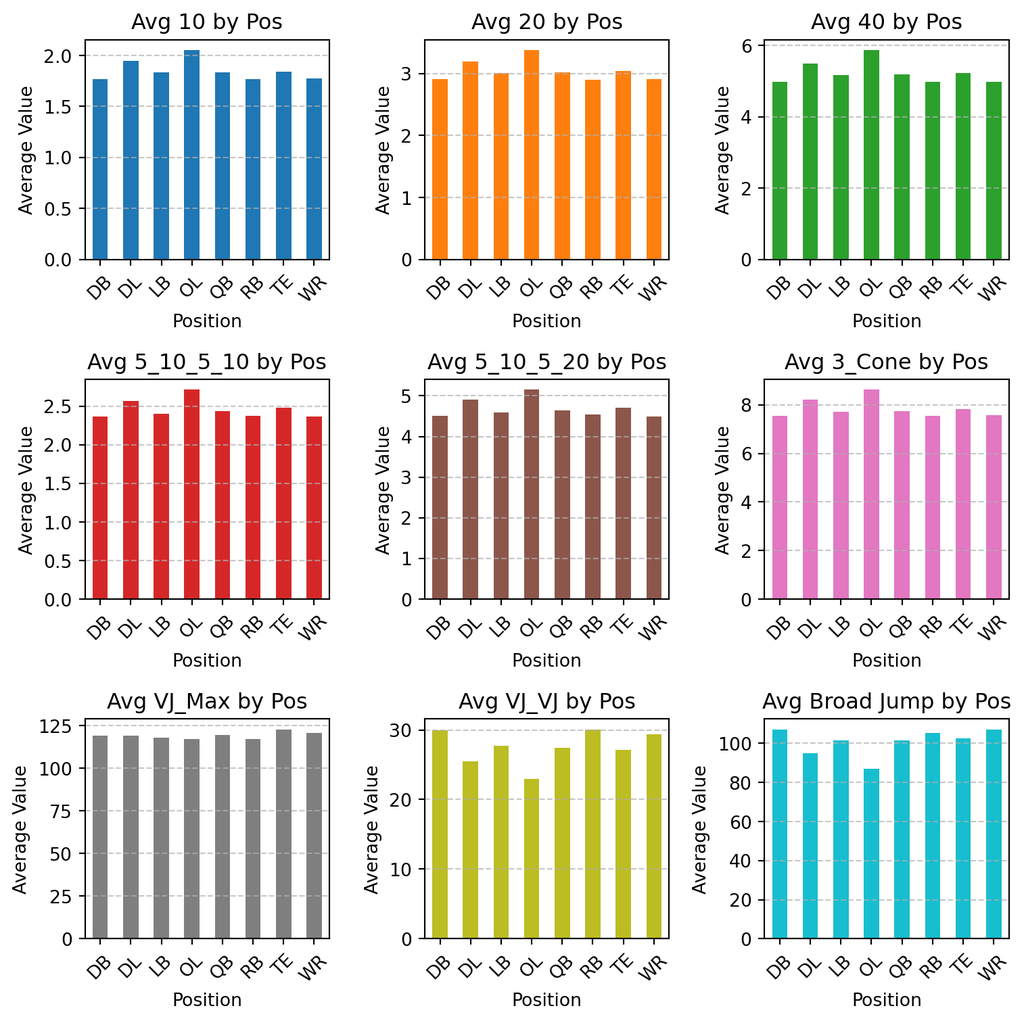

```python
import matplotlib.pyplot as plt
import numpy as np

# Calculate the average for each unique position
numeric_columns_avg = combine.groupby('Position')[numeric_columns].mean()

# Determine grid dimensions
num_rows = 3
num_cols = 3

# Create subplots
fig, axes = plt.subplots(num_rows, num_cols, figsize=(8, 8))

# Define a colormap
colors = plt.cm.tab10(np.linspace(0, 1, len(numeric_columns)))

# Plotting each numeric column in a separate subplot
for i, (column, color) in enumerate(zip(numeric_columns, colors)):
    row = i // num_cols
    col = i % num_cols
    ax = axes[row, col]
    numeric_columns_avg[[column]].plot(kind='bar', ax=ax, legend=False, color=color)
    ax.set_title(f'Avg {column} by Pos')
    ax.set_xlabel('Position')
    ax.set_ylabel('Average Value')
    ax.tick_params(axis='x', rotation=45)
    ax.grid(axis='y', linestyle='--', alpha=0.7)

# Adjust layout
plt.tight_layout()
plt.show()
```

| Position | 10 | 20 | 40 | 5_10_5_10 | 5_10_5_20 | 3_Cone | VJ_Max | VJ_VJ | Broad Jump |
| --- | --- | --- | --- | --- | --- | --- | --- | --- | --- |
| DB | 1.768603 | 2.904717 | 4.978761 | 2.365636 | 4.507364 | 7.544592 | 119.101322 | 29.932890 | 107.062500 |
| DL | 1.948025 | 3.190907 | 5.495855 | 2.572099 | 4.900315 | 8.201370 | 118.967914 | 25.464199 | 94.746914 |
| LB | 1.832971 | 3.011575 | 5.172703 | 2.405935 | 4.596814 | 7.721183 | 117.944444 | 27.738389 | 101.503268 |
| OL | 2.053721 | 3.379012 | 5.872859 | 2.713466 | 5.149279 | 8.620065 | 117.023077 | 22.927013 | 86.950147 |
| QB | 1.832539 | 3.017943 | 5.192307 | 2.435299 | 4.637402 | 7.734085 | 119.380165 | 27.393415 | 101.314433 |
| RB | 1.767177 | 2.898472 | 4.976106 | 2.377870 | 4.535204 | 7.556855 | 117.123626 | 30.069907 | 105.106195 |
| TE | 1.844067 | 3.036289 | 5.233533 | 2.483667 | 4.701044 | 7.820489 | 122.689655 | 27.116905 | 102.400000 |
| WR | 1.775830 | 2.911844 | 4.980886 | 2.370128 | 4.497860 | 7.568879 | 120.494361 | 29.364390 | 106.899767 |

To uncover whether high scool combine test scores have a statistically significant effect on a player’s future performance, a two-tailed t-test was used on each position and metric grouping between the successful and unsuccessful players. The two tailed tests have the following null hypotheses:

**Null Hypothesis** $H_0$: $\mu_1 = \mu_2$ (There is no significant difference between the mean test scores of successful players and unsuccessful players).

**Alternative Hypothesis** $H_a$: $\mu_1 \neq \mu_2$ (There is a significant difference between the mean test scores of successful players and unsuccessful players).

```python
## The following is commented out due to the size of the output and runtime

# from scipy.stats import ttest_ind

# # Iterate over each unique position
# for position in combine['Position'].unique():
#     # Filter data for successful and unsuccessful players for the current position
#     successful_players_pos = successful_players[successful_players['Position'] == position][numeric_columns].dropna()
#     unsuccessful_players_pos = unsuccessful_players[unsuccessful_players['Position'] == position][numeric_columns].dropna()

#     # Convert columns to numeric type and drop non-convertible values
#     successful_players_pos = successful_players_pos.apply(pd.to_numeric, errors='coerce').dropna()
#     unsuccessful_players_pos = unsuccessful_players_pos.apply(pd.to_numeric, errors='coerce').dropna()

#     # Perform t-tests for each numeric column
#     for column in numeric_columns:
#         # Perform t-test
#         t_stat, p_value = ttest_ind(successful_players_pos[column], unsuccessful_players_pos[column], equal_var=False)

#         # Print results
#         print(f"Position: {position}, Column: {column}")
#         print(f"T-statistic: {t_stat}")
#         print(f"P-value: {p_value}")
#         print("")

#         # Check if the difference is statistically significant
#         if p_value < 0.05:
#             print("The difference is statistically significant.")
#         else:
#             print("The difference is not statistically significant.")
#         print("\n")
```

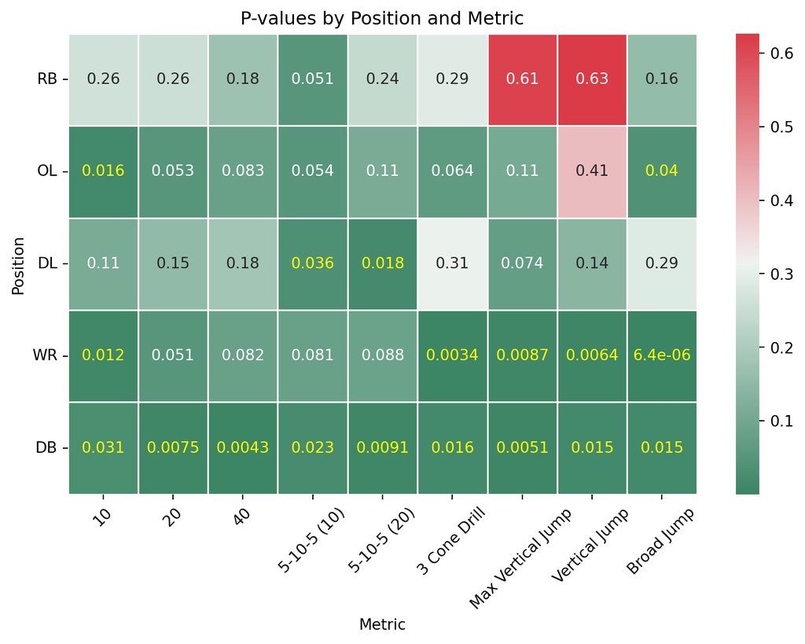

```python
import pandas as pd
import seaborn as sns

# Data dictionary
data = {
    'Position': ['RB', 'OL', 'DL', 'WR', 'DB'],
    '10': [0.263058544, 0.015908057, 0.112437563, 0.011776909, 0.031190147],
    '20': [0.256563976, 0.053341917, 0.153893937, 0.050846528, 0.007506925],
    '40': [0.175873094, 0.082631773, 0.183316958, 0.081739617, 0.004294826],
    '5-10-5 (10)': [0.05059933, 0.053562364, 0.035655229, 0.081064974, 0.023101482],
    '5-10-5 (20)': [0.241835479, 0.110190885, 0.018160605, 0.087525887, 0.009063921],
    '3 Cone Drill': [0.289008859, 0.063712041, 0.310293884, 0.003414336, 0.015756057],
    'Max Vertical Jump': [0.614199951, 0.105957498, 0.074106854, 0.008727837, 0.005073257],
    'Vertical Jump': [0.626614448, 0.405807566, 0.137799545, 0.006410804, 0.014728847],
    'Broad Jump': [0.156670964, 0.039524933, 0.28772801, 6.44E-06, 0.01517466]
}

# Convert data to DataFrame
df = pd.DataFrame(data)

# Set Position column as index
df.set_index('Position', inplace=True)

# Create custom colormap going from red to green
cmap = sns.diverging_palette(150, 10, as_cmap=True)

# Create heatmap
plt.figure(figsize=(8, 6))
heatmap = sns.heatmap(df, cmap=cmap, annot=True, cbar=True, linewidths=0.5)

# Highlight values below 0.05 in darker green color
for text in heatmap.texts:
    value = float(text.get_text())
    if value < 0.05:
        text.set_color('Yellow')

plt.title('P-values by Position and Metric')
plt.xlabel('Metric')
plt.ylabel('Position')
plt.xticks(rotation=45)
plt.yticks(rotation=0)
plt.tight_layout()

# Show plot
plt.show()
```

Values with text in yellow had p-values below 0.05, meaning that we could conclude that the differences between successful and unsuccessful players within that position group are significantly different for that combine metric. These significant groupings are displayed again in the following heatmap, displaying as the value 1. These groupings should be paid close attention to during the scouting process, as they are a significant indicator of a player’s success at the next levels.

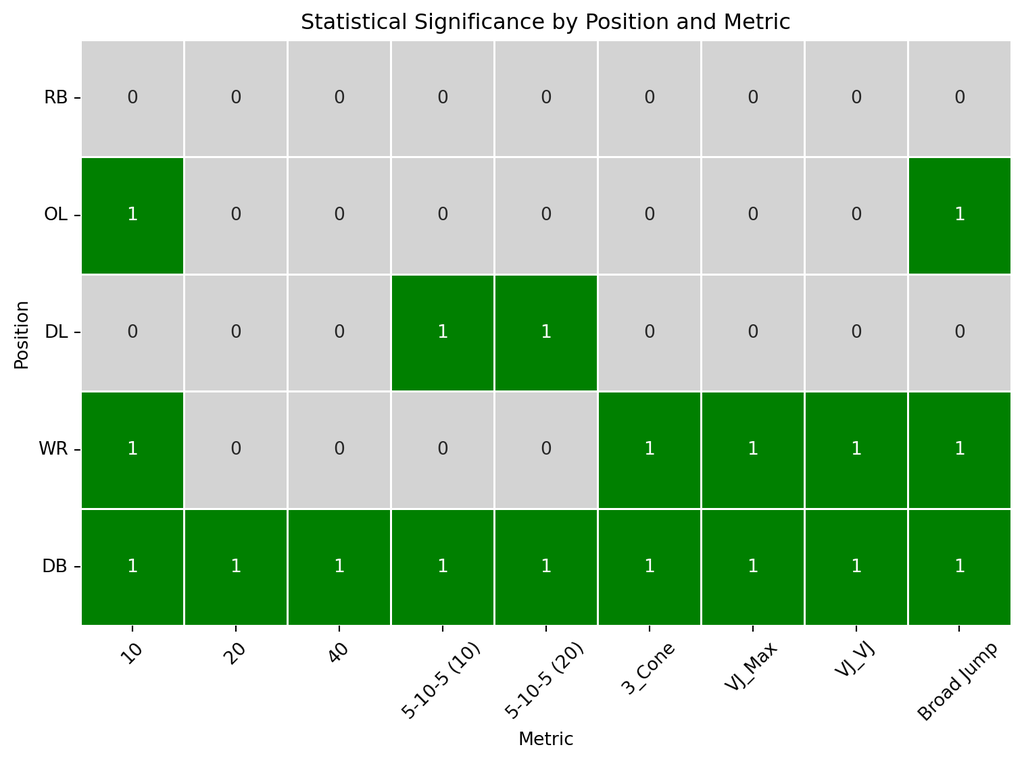

```python
import numpy as np
import pandas as pd
import seaborn as sns
import matplotlib.pyplot as plt

# Data dictionary
data = {
    'Position': ['RB', 'OL', 'DL', 'WR', 'DB'],
    '10': ['Not Significant', 'Significant', 'Not Significant', 'Significant', 'Significant'],
    '20': ['Not Significant', 'Not Significant', 'Not Significant', 'Not Significant', 'Significant'],
    '40': ['Not Significant', 'Not Significant', 'Not Significant', 'Not Significant', 'Significant'],
    '5-10-5 (10)': ['Not Significant', 'Not Significant', 'Significant', 'Not Significant', 'Significant'],
    '5-10-5 (20)': ['Not Significant', 'Not Significant', 'Significant', 'Not Significant', 'Significant'],
    '3_Cone': ['Not Significant', 'Not Significant', 'Not Significant', 'Significant', 'Significant'],
    'VJ_Max': ['Not Significant', 'Not Significant', 'Not Significant', 'Significant', 'Significant'],
    'VJ_VJ': ['Not Significant', 'Not Significant', 'Not Significant', 'Significant', 'Significant'],
    'Broad Jump': ['Not Significant', 'Significant', 'Not Significant', 'Significant', 'Significant']
}

# Convert data to DataFrame
df = pd.DataFrame(data)

# Set Position column as index
df.set_index('Position', inplace=True)

# Define colors for the heatmap
colors = {'Significant': 1, 'Not Significant': 0, 'N/A': np.nan}

# Map colors to DataFrame
df_mapped = df.replace(colors)

# Create heatmap
plt.figure(figsize=(8, 6))
heatmap = sns.heatmap(df_mapped, cmap=['lightgrey', 'green'], annot=True, cbar=False, linewidths=0.5)
plt.title('Statistical Significance by Position and Metric')
plt.xlabel('Metric')
plt.ylabel('Position')
plt.xticks(rotation=45)
plt.yticks(rotation=0)
plt.tight_layout()

# Show plot
plt.show()
```

# Discussion

This analysis discovered that the significance of combine metrics vary greatly among positions. Certain tests have predictive power among particular positions, but not others. Additionally, some positions’ see consistently more significance across the majority of tests than others. For example, every average combine test significantly differs between successful and unsuccessful defensive backs, but none of these tests significantly differ between successful and unsuccessful running backs.

The following combine tests should be used in prospect scouting at the following positions:

- 40-yard dash (10-yard split): Offensive Lineman, Wide Receiver, Defensive Back
- 40-yard dash (20-yard split): Defensive Back
- 40-yard dash: Defensive Back
- 20 Yard Shuffle (10-yard split): Defensive Lineman, Defensive Back
- 20 Yard Shuffle: Defensive Lineman, Defensive Back
- 3-Cone Drill: Wide Receiver, Defensive Back
- Vertical Jump (Sum): Wide Receiver, Defensive Back
- Vertical Jump (Average): Wide Receiver, Defensive Back
- Broad Jump: Offesnive Lineman, Wide Receiver, Defensive Back

There are some limitations to this study. Due to a small sample size of successful players at certain positions, not all types of players could be considered. Also, players had to be placed into generalized groupings in order to reach an adequate sample size at certain positions. For example, slot cornerbackss, outside cornerbacks, strong safeties, and free safeties are all aggregated into one position. Each of these positions require players of different skill sets and athletic traits. Additionally, only four conferences’ postseason awards were taken into account. This meant that if a player was to be named to their All-Conference team in an alternative conference (i.e., SEC, Big 10, Pac-12, ACC) but not invited to the NFL combine, their post high school playing career would have been marked as unsuccessful. Therefore we can assume that there may be some players in the unsuccessful pool who should have been in the successful pool. Luckily, most players who are bestowed with these honors in these power conferences are often invited to the combine.

# Conclusion

This analysis effectively selected metrics for scouts to key in on during the recruitment process. Instead of allocating time and personnel resources toward pouring over insignificant tests, collegiate teams can identify potenential star players by focusing on these significance combine metrics. Although it is unlikely that every player on a roster will be able to stand out at each of these test scores, having a higher ratio of player personnel that does fulfill these requirements could lead to greater team success.